# Tracts

Steve Simon and Satya Golla

12/30/2021

```r
library(sf)
library(tidyverse)
```

### Census tracts

A Census tract is a region usually within a single county that contains roughly 4,000 people. There are files for census tracts for [Kansas][c_tract_ks] and [Missouri][c_tract_mo]. The various functions described in the US counties shapefiles section will be used here.

```r
path_name <- "./data"
file_name <- "tl_2021_20_tract.shp"
path_name                              %>%
  paste(file_name, sep="/")            %>%
  st_read(stringsAsFactors=FALSE)      -> all_tract_ks
head(all_tract_ks)
```

```
## Simple feature collection with 6 features and 12 fields
## Geometry type: POLYGON
## Dimension:     XY
## Bounding box:  xmin: -99.38456 ymin: 36.99907 xmax: -95.33963 ymax: 40.00047
## Geodetic CRS:  NAD83
##   STATEFP COUNTYFP TRACTCE       GEOID NAME          NAMELSAD MTFCC FUNCSTAT
## 1      20      147  475300 20147475300 4753 Census Tract 4753 G5020        S
## 2      20      125  951300 20125951300 9513 Census Tract 9513 G5020        S
## 3      20      013  480600 20013480600 4806 Census Tract 4806 G5020        S
## 4      20      013  480700 20013480700 4807 Census Tract 4807 G5020        S
## 5      20      013  480800 20013480800 4808 Census Tract 4808 G5020        S
## 6      20      125  950300 20125950300 9503 Census Tract 9503 G5020        S
##       ALAND  AWATER    INTPTLAT     INTPTLON                       geometry
## 1  63819685       0 +39.7489242 -099.3379560 POLYGON ((-99.38456 39.7799...
## 2  49864039  450551 +37.0308415 -095.9198925 POLYGON ((-95.96475 37.0159...
## 3 882291723 1376795 +39.8596443 -095.6255187 POLYGON ((-95.78905 39.7497...
## 4  65482983   78983 +39.8545254 -095.5450126 POLYGON ((-95.60171 39.8268...
## 5 530775368 1740369 +39.7619242 -095.4599814 POLYGON ((-95.62039 39.6639...
## 6  24901112  210474 +37.2466193 -095.7275991 POLYGON ((-95.76786 37.2597...
```

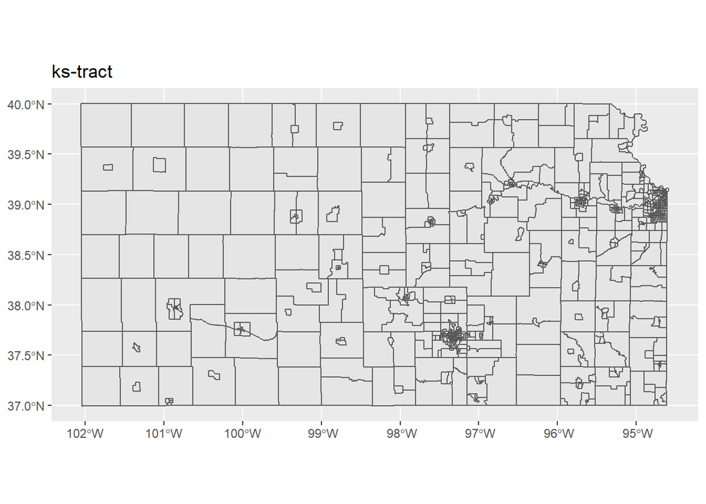

```r
all_tract_ks                           %>%
     ggplot()                              +
      geom_sf(aes())                    +
      ggtitle("ks-tract")
```

```r
path_name <- "./data"
file_name <- "tl_2021_29_tract.shp"
path_name                              %>%
  paste(file_name, sep="/")            %>%
  st_read(stringsAsFactors=FALSE)      -> all_tract_mo
head(all_tract_mo)
```

```
## Simple feature collection with 6 features and 12 fields
## Geometry type: POLYGON
## Dimension:     XY
## Bounding box:  xmin: -89.97248 ymin: 36.33681 xmax: -89.32748 ymax: 36.87091
## Geodetic CRS:  NAD83
##   STATEFP COUNTYFP TRACTCE       GEOID NAME          NAMELSAD MTFCC FUNCSTAT
## 1      29      143  960400 29143960400 9604 Census Tract 9604 G5020        S
## 2      29      143  960300 29143960300 9603 Census Tract 9603 G5020        S
## 3      29      143  960100 29143960100 9601 Census Tract 9601 G5020        S
## 4      29      143  960600 29143960600 9606 Census Tract 9606 G5020        S
## 5      29      143  960200 29143960200 9602 Census Tract 9602 G5020        S
## 6      29      143  960500 29143960500 9605 Census Tract 9605 G5020        S
##       ALAND   AWATER    INTPTLAT     INTPTLON                       geometry
## 1 377022336 21561597 +36.5088909 -089.6662818 POLYGON ((-89.86732 36.5532...
## 2  38755026  2428968 +36.5880623 -089.5616904 POLYGON ((-89.61003 36.5868...
## 3 287891722   370686 +36.7977595 -089.5923578 POLYGON ((-89.70483 36.8592...
## 4  15146537    60482 +36.4481560 -089.6873596 POLYGON ((-89.71113 36.4232...
## 5 548642900 28908393 +36.6478272 -089.5177175 POLYGON ((-89.70268 36.7390...
## 6 480482378  2906167 +36.4871669 -089.8521238 POLYGON ((-89.97248 36.3896...
```

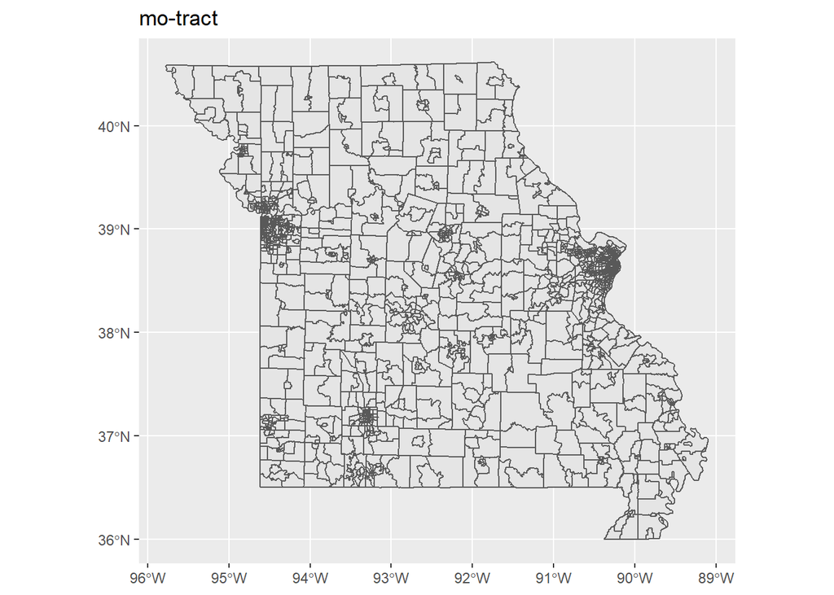

```r
all_tract_mo                           %>%
     ggplot()                              +
      geom_sf(aes())                    +
      ggtitle("mo-tract")
```

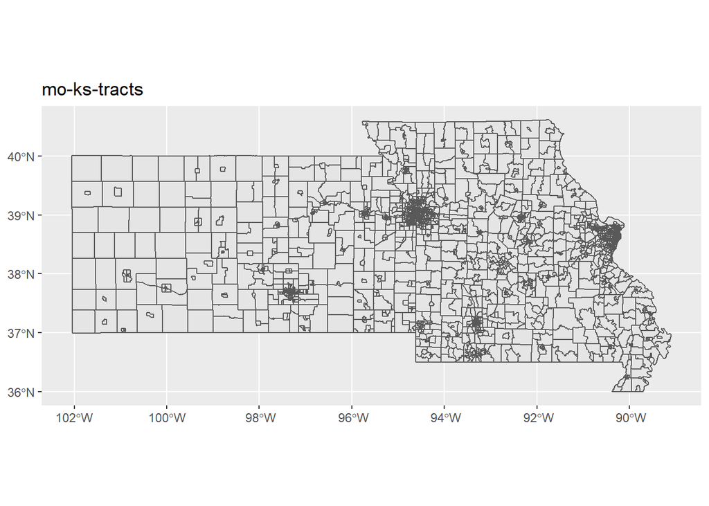

```r
all_tract_ks                           %>%
  bind_rows(all_tract_mo)  -> mo_ks_tracts
mo_ks_tracts                           %>%
 ggplot()                               +
      geom_sf(aes())                    +
      ggtitle("mo-ks-tracts")
```

### Community districts

This shapefile, Community_District, was provided by Neal Wilson. The various functions described in the US counties shapefiles section will be used here.

```r
file_name <- "Community_District.shp"
path_name                              %>%
  paste(file_name, sep="/")            %>%
  st_read(stringsAsFactors=FALSE)      -> Community_Districts
head(Community_Districts)
```

```
## Simple feature collection with 6 features and 8 fields
## Geometry type: POLYGON
## Dimension:     XYZ
## Bounding box:  xmin: 2758255 ymin: 1013899 xmax: 2821302 ymax: 1086876
## z_range:       zmin: 0 zmax: 0
## Projected CRS: NAD_1983_StatePlane_Missouri_West_FIPS_2403_Feet
##   State STATE_FIPS CD_ID
## 1    MO         29   106
## 2    MO         29   108
## 3    MO         29   113
## 4    MO         29   102
## 5    MO         29   129
## 6    MO         29   116
##                                                                                 shid
## 1            country:us/state:mo/place:kansas_city_city/community_district:east_side
```

[output cut: 19 more lines]

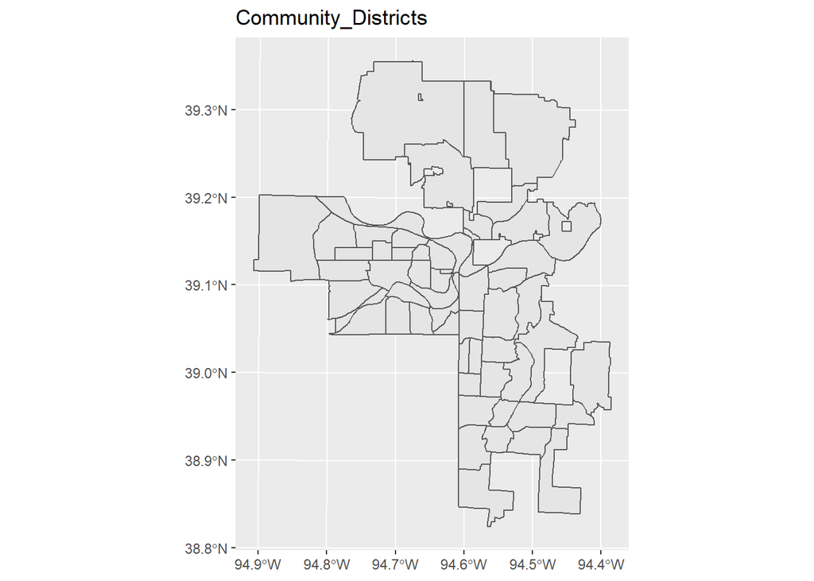

```r
Community_Districts                  %>%
  ggplot()                              +
      geom_sf(aes())                    +
      ggtitle("Community_Districts")
```

```r
Community_Districts %>%
  st_transform(crs=st_crs(mo_ks_tracts)) -> cd
```

### Calculate intersections

#### Intersection of tracts with community districts

Each community district will reside entirely inside a single county, and it is obvious to anyone familiar with the Kansas City metropolitan area which county is would be, so this is done mostly for the sake of continuity and completeness.

It is important that both the tracts and the community districts use a common coordinate reference system. It is uncelar WHICH coordinate reference system is best, but this is controlled by the st_crs function of the sf package.

The st_intersects function will evaluate to TRUE if two shapefiles intersect. The st_area function will give the area of a shapefile and the st_intersection function will produce a new shapefile from the intersection of two shapefiles.

```
## st_as_s2(): dropping Z and/or M coordinate
```

```
## Units: [m^2]
##  [1] 1.2765914280 1.6600508764 1.3321484926 0.9561327832 1.2801775196
##  [6] 1.4570354177 1.2505911353 0.6390269816 0.6451667293 0.6397489096
## [11] 0.0043428180 0.0006149019 1.3508118643 0.6386280859 1.3195643251
## [16] 0.6371822032 0.6441345903 1.5635983961 0.6401416586 1.2776740681
## [21] 1.1071550959 1.3365572568 0.7850781986 0.8981508086 0.6639980962
## [26] 0.0001535346 0.0004669085 2.1482320160
## Units: [m^2]
##  [1] 1.2765914 2.4365608 1.3332304 1.2829212 1.2806959 1.9017633 1.2505911
##  [8] 0.6395731 0.6451667 0.6397489 1.2714303 1.5510860 1.4603075 0.6386281
## [15] 1.4550890 0.6371822 0.6446925 2.4458801 0.6401417 1.2776741 1.1071551
## [22] 1.3377622 1.7503011 1.2791522 0.6639981 1.2962605 2.0329193 4.5200377
## Units: [1]
##  [1] 1.0000000000 0.6813090277 0.9991885424 0.7452778736 0.9995952609
##  [6] 0.7661497177 1.0000000000 0.9991461424 1.0000000000 0.9999999994
## [11] 0.0034156949 0.0003964332 0.9250188001 1.0000000000 0.9068615798
## [16] 1.0000000000 0.9991345668 0.6392784254 1.0000000000 1.0000000000
## [21] 1.0000000000 0.9990992529 0.4485389514 0.7021453631 1.0000000002
## [26] 0.0001184443 0.0002296739 0.4752686039
```

```
## st_as_s2(): dropping Z and/or M coordinate
```

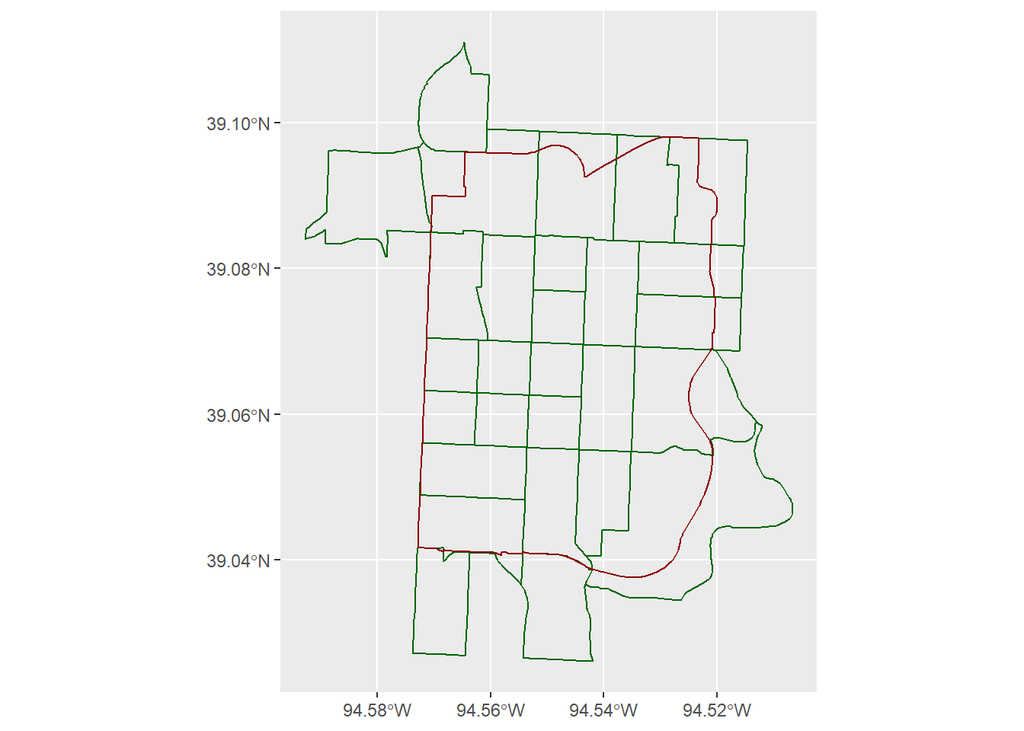

```
## Units: [m^2]
##  [1] 0.006738103 0.278242383 0.444727886 0.109403046 1.559744916 0.008735667
##  [7] 1.224979631 1.402110828 1.332286952 1.313160217 0.990689439 1.273551710
## [13] 0.662469150 0.369716767
## Units: [m^2]
##  [1] 26.6174571  2.4365608  1.9017633  1.4603075  1.5607991  1.7162974
##  [7]  1.2251172  1.4026942  1.3323051  1.3132515  0.9906894  1.7319849
## [13]  0.6624691  1.2962605
## Units: [1]
##  [1] 0.000253146 0.114194722 0.233850282 0.074917816 0.999324564 0.005089833
##  [7] 0.999887738 0.999584106 0.999986346 0.999930518 1.000000000 0.735313414
## [13] 1.000000000 0.285217954
```

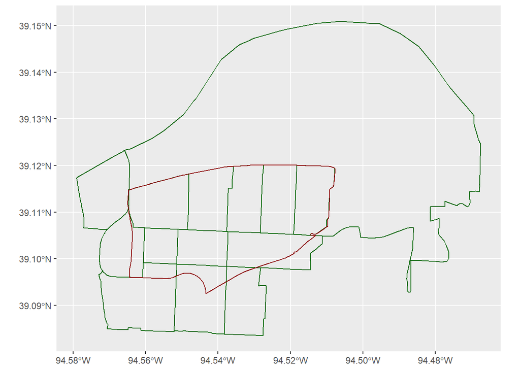

```r
for (i in 1:2) {
mo_ks_tracts                                   %>%
  st_intersects( cd[i,], sparse=FALSE) -> intersect_matrix
  total_area  <- st_area(mo_ks_tracts[intersect_matrix,]) / 1000000
  intersect_area <- st_area(st_intersection(mo_ks_tracts[intersect_matrix,],cd[i,])) / 1000000
  print(intersect_area)
  print(total_area)
  print(intersect_area/total_area)
  mo_ks_tracts[intersect_matrix,]               %>%
    ggplot(aes())  +
      geom_sf(fill=NA, col="darkgreen")      +
      geom_sf(data = cd[i,], fill=NA, col="darkred")  -> map
  print(map)}
```